# Cancelaciones catastróficas

# Iker Sebastian Bali Elizalde

# A01656437

### 1. El programa inicial

```python
import numpy as np
import matplotlib.pyplot as plt
import math
import pandas as pd



plt.style.use("default")


def expmac(array,iters):
    suma=0
    for i in range(iters):
        r=((array)**i)/(math.factorial(i))
        suma=suma+r
    return suma

def expast(array,iters):
    array=-1*array
    return 1/expmac(array,iters)
```

### 2. Problema Base

Empecemos por calcular la función exponencial para números positivos. Usa números de la siguiente lista $x={.01,0.1,.5,1,2,5,10}$

Calcula el valor aproximado de la función usando un número diferente de términos:

$N={0,1,2,...10}$

Despliega el resultado como una gráfica donde el eje horizontal corresponde al número de términos y el vertical al valor aproximado. Usa una línea horizontal para mostrar el valor exacto.

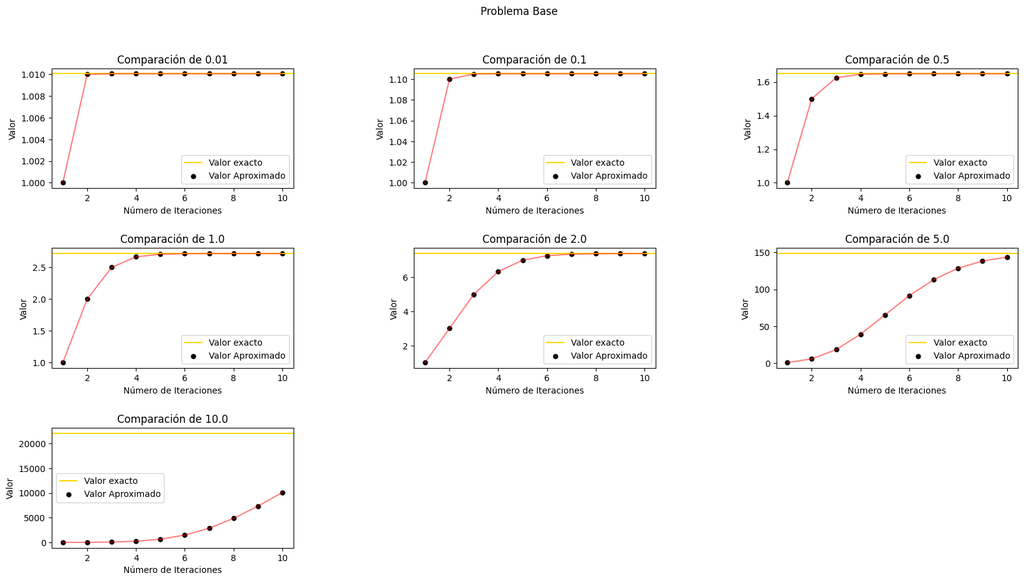

```python
x=np.array([.01,0.1,.5,1,2,5,10])
u=np.arange(1,8,1)

plt.figure(figsize=(20, 10))
plt.suptitle("Problema Base")

for j,w in zip(x,u):
    yaprox=[]
    for i in range(1,11):
        y=expmac(j,i)
        yaprox.append(y)

    t=np.arange(1,11,1)

    plt.subplot(3,3,w)
    plt.title("Comparación de " + str(j))
    plt.xlabel("Número de Iteraciones")
    plt.ylabel("Valor")
    plt.axhline(np.exp(j),color="gold",label="Valor exacto")
    plt.scatter(t,yaprox,s=25,color="black",label="Valor Aproximado")
    plt.plot(t,yaprox,alpha=0.5,color="red")
    plt.legend()
plt.subplots_adjust(hspace=0.5, wspace=0.5)
plt.show()
```

Para cada aproximación, calcula el error relativo:

$\varepsilon = \left| \frac{y_{app}-y_{ex}}{y_{app}} \right|$

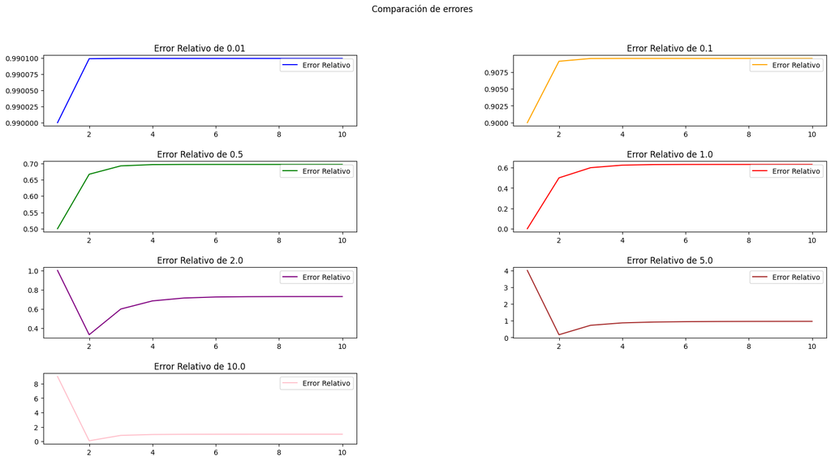

```python
errores=[]
x=np.array([.01,0.1,.5,1,2,5,10])

yaprox=[]
for i in range(1,11):
    y=expmac(x,i)
    yaprox.append(y)


for a in yaprox:
    error=np.abs((x-a)/a)
    errores.append(error)


x=np.array([.01,0.1,.5,1,2,5,10])
errores_pro=np.transpose(errores)

colores = ['blue', 'orange', 'green', 'red', 'purple', 'brown', 'pink']

r=np.arange(1,11,1)
s=np.arange(1,11,1)


plt.figure(figsize=(20, 10))

for i,j,k,l in zip(errores_pro,s,x,colores):
    plt.subplot(4,2,j)
    plt.plot(r,i,label="Error Relativo",color=l)
    plt.title("Error Relativo de " + str(k))
    plt.suptitle("Comparación de errores")
    plt.legend()
plt.subplots_adjust(hspace=0.5, wspace=0.5)
plt.show()
```

3. Problema complicado: solución ingenua Ahora vamos a calcular la función exponencial para números negativos. Usa números de la siguiente lista x={ -.01,-0.1,-.5,-1,-2,-5,-10}. Repite los pasos del inciso anterior.

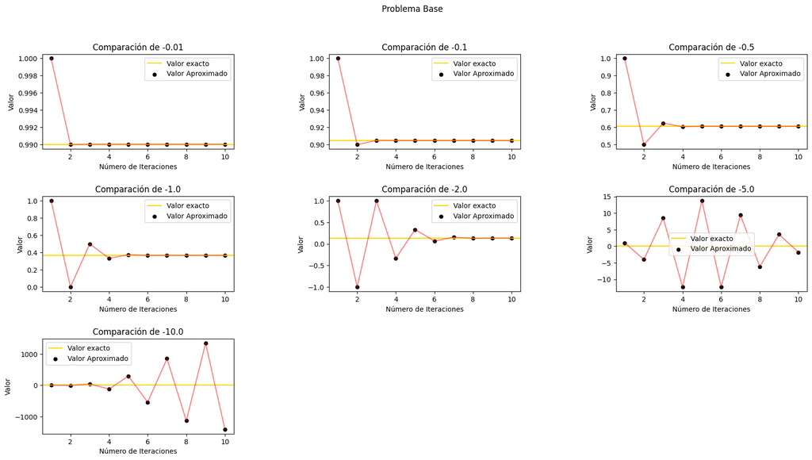

```python
x=np.array([-.01,-0.1,-.5,-1,-2,-5,-10])
u=np.arange(1,8,1)

plt.figure(figsize=(20, 10))
plt.suptitle("Problema Base")

for j,w in zip(x,u):
    yaprox=[]
    for i in range(1,11):
        y=expmac(j,i)
        yaprox.append(y)

    t=np.arange(1,11,1)

    plt.subplot(3,3,w)
    plt.title("Comparación de " + str(j))
    plt.xlabel("Número de Iteraciones")
    plt.ylabel("Valor")
    plt.axhline(np.exp(j),color="gold",label="Valor exacto")
    plt.scatter(t,yaprox,s=25,color="black",label="Valor Aproximado")
    plt.plot(t,yaprox,alpha=0.5,color="red")
    plt.legend()
plt.subplots_adjust(hspace=0.5, wspace=0.5)
plt.show()
```

Error Relativo

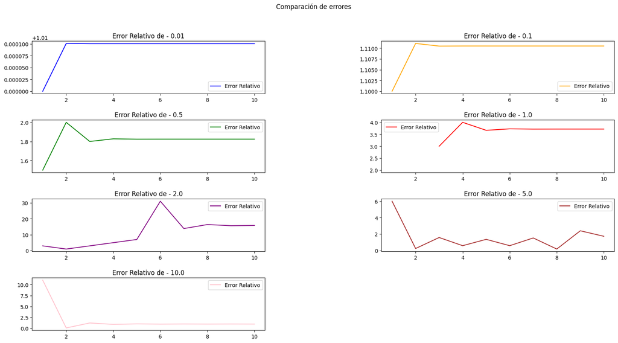

```python
errores=[]
x=np.array([-.01,-0.1,-.5,-1,-2,-5,-10])

yaprox=[]
for i in range(1,11):
    y=expmac(x,i)
    yaprox.append(y)


for a in yaprox:
    error=np.abs((x-a)/a)
    errores.append(error)


x=np.array([.01,0.1,.5,1,2,5,10])
errores_pro=np.transpose(errores)

colores = ['blue', 'orange', 'green', 'red', 'purple', 'brown', 'pink']

r=np.arange(1,11,1)
s=np.arange(1,11,1)


plt.figure(figsize=(20, 10))

for i,j,k,l in zip(errores_pro,s,x,colores):
    plt.subplot(4,2,j)
    plt.plot(r,i,label="Error Relativo",color=l)
    plt.title("Error Relativo de - " + str(k))
    plt.suptitle("Comparación de errores")
    plt.legend()
plt.subplots_adjust(hspace=0.5, wspace=0.5)
plt.show()
```

4. Problema complicado: solución astuta

Calcula el mismo problema anterior con la estrategia vista en clase, i.e. expresar $e^{-x}=\frac{1}{e^x}$, y usar esto para usar las series 'decentes' del inciso 2. Despliega los resultados y comenta las diferencias. Nota: Puedes combinar los resultados de los incisos 3 y 4 en un solo conjunto de gráficas. Usa líneas de diferentes colores para diferenciar la estrategia que estas usando.

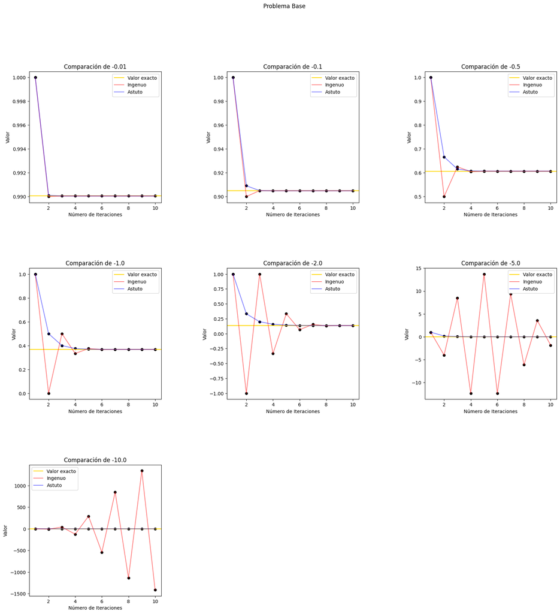

```python
x=np.array([-.01,-0.1,-.5,-1,-2,-5,-10])
u=np.arange(1,8,1)

plt.figure(figsize=(20, 20))
plt.suptitle("Problema Base")

for j,w in zip(x,u):
    yaprox=[]
    yast=[]
    for i in range(1,11):
        y=expast(j,i)
        y2=expmac(j,i)
        yaprox.append(y2)
        yast.append(y)

    t=np.arange(1,11,1)

    plt.subplot(3,3,w)
    plt.title("Comparación de " + str(j))
    plt.xlabel("Número de Iteraciones")
    plt.ylabel("Valor")
    plt.axhline(np.exp(j),color="gold",label="Valor exacto")
    plt.scatter(t,yaprox,s=25,color="black")
    plt.plot(t,yaprox,alpha=0.5,color="red",label="Ingenuo")
    plt.scatter(t,yast,s=25,color="black")
    plt.plot(t,yast,alpha=0.5,color="blue",label="Astuto")
    plt.legend()
plt.subplots_adjust(hspace=0.5, wspace=0.5)
plt.show()
```

5,6. Una exploración más detallada

```python
yingenua=[]
yastuta=[]
x=np.arange(-20,20.1,0.1)
yteorica=np.exp(x)

for i in range(1,51,1):
    a=expmac(x,i)
    b=expast(x,i)
    yingenua.append(a)
    yastuta.append(b)


Eingenuo=[]
Eastuto=[]

for i in range(len(yastuta)):
    errorastuto=np.abs((yteorica-yastuta[i])/yastuta[i])
    erroringenuo=np.abs((yteorica-yingenua[i])/yingenua[i])
    Eastuto.append(errorastuto)
    Eingenuo.append(erroringenuo)
```

[figure not shown]

```python
Eingenuo=np.array(Eingenuo)
Eingenuo=np.flip(Eingenuo,axis=1)
Eingenuopro=pd.DataFrame(Eingenuo,index=np.arange(1,51,1),columns=x)
Eingenuopro=Eingenuopro.map(np.log10)
Eingenuopro.replace(-np.inf, -100, inplace=True)
Eingenuopro=np.where(Eingenuopro<=-15,-15,Eingenuopro)
Eingenuopro=np.where(Eingenuopro>=15,15,Eingenuopro)


plt.figure()
pcm = plt.pcolormesh(x, range(50), Eingenuopro, vmin=-15, vmax=15, cmap="bwr")
plt.xlabel("Valor")
plt.ylabel("Número de Iteraciones")
plt.contour(x, range(50), Eingenuopro, levels=[np.log(0.01)], cmap="gray",label="Rango válido")
plt.title("Método Astuto")

# Agregar el colorbar para el gráfico pcolormesh
cbar = plt.colorbar(pcm)
cbar.set_label('Magnitud del Error')

plt.legend()
plt.show()
```

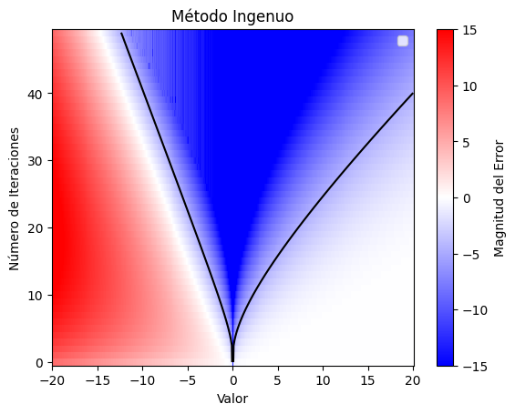

```python
import numpy as np
import pandas as pd
import matplotlib.pyplot as plt

Eastuto = np.array(Eastuto)
Eastuto = np.flip(Eastuto, axis=1)
Eastuto_pro = pd.DataFrame(Eastuto, index=np.arange(1, 51, 1), columns=x)
Eastuto_pro = Eastuto_pro.applymap(np.log10)
Eastuto_pro.replace(-np.inf, -100, inplace=True)
Eastuto_pro = np.where(Eastuto_pro <= -15, -15, Eastuto_pro)
Eastuto_pro = np.where(Eastuto_pro >= 15, 15, Eastuto_pro)

plt.figure()
pcm = plt.pcolormesh(x, range(50), Eastuto_pro, vmin=-15, vmax=15, cmap="bwr")
plt.xlabel("Valor")
plt.ylabel("Número de Iteraciones")
plt.contour(x, range(50), Eastuto_pro, levels=[np.log(0.01)], cmap="gray", label="Rango válido")
plt.title("Método Ingenuo")

# Agregar el colorbar para el gráfico pcolormesh
cbar = plt.colorbar(pcm)
cbar.set_label('Magnitud del Error')

plt.legend()
plt.show()
```

Se puede obsevar que en el método ingenuo, las iteraciones en números negativos debe ser muy grande para que el error no sea mayor, esto por el hecho de ser ingenuo, así que no se recomienda usar esta forma en numeros negativos, en números positivos realmente no hay problema, ambos métodos funcionan, pero en los negativos solo en valores pequeños hay una buena convergencia.